# Science, Data, Tools

or *'Tips and tricks for a your everyday workflow'*

# Prologue

AKA *My Research*

## The cumulant expansion

The struggle has been too long, but we are starting to see the light...

## As you might recall...

We are trying to go beyond the GW approximation

and succeed in describing satellites.

## The spectral function

It looks like this: \begin{equation} A(\omega) = \mathrm{Im}|G(\omega)| \end{equation}

## GW vs Cumulant

Mathematically very different:

\begin{equation} G^{GW} (\omega) = \frac1{ \omega - \epsilon - \Sigma (\omega) } \end{equation}

\begin{equation} G^C(t_1, t_2) = G^0(t_1, t_2) e^{ i \int_{t_1}^{t_2} \int_{t'}^{t_2} dt' dt'' W (t', t'') } \end{equation}

BUT they connect through $\mathrm{Im} W (\omega) = \frac1\pi \mathrm{Im} \Sigma ( \epsilon - \omega )$.

[Guzzo et al., Phys. Rev. Lett. 107, 166401, 2011](http://journals.aps.org/prl/abstract/10.1103/PhysRevLett.107.166401)

## Implementation

Using a multi-pole representation for $\Sigma^{GW}$:

\begin{equation} \mathrm{Im} W (\omega) = \frac1\pi \mathrm{Im} \Sigma ( \epsilon - \omega ) \end{equation}\begin{equation} W (\tau) = - i \lambda \bigl[ e^{ i \omega_p \tau } \theta ( - \tau ) + e^{ - i \omega_p \tau } \theta ( \tau ) \bigr] \end{equation}

## GW vs Cumulant

- GW:

\begin{equation} A(\omega) = \frac1\pi \frac{\mathrm{Im}\Sigma (\omega)} { [ \omega - \epsilon - \mathrm{Re}\Sigma (\omega) ]^2 + [ \mathrm{Im}\Sigma (\omega) ]^2} \end{equation}

- Cumulant (plasmon-pole):

\begin{equation} A(\omega) = \frac1\pi \sum_{n=0}^{\infty} \frac{a^n}{n!} \frac{\Gamma}{ (\omega - \epsilon + n \omega_p)^2 + \Gamma^2 } \end{equation}

## Problems

\begin{equation} A(\omega) = \frac1\pi \sum_{n=0}^{\infty} \frac{a^n}{n!} \frac{\Gamma}{ (\omega - \epsilon + n \omega_p)^2 + \Gamma^2 } \end{equation}

## Alternative: full numerical

With $ t = t_2 - t_1 $:

\begin{equation} G^C (t) = G^0(t) e^{ i \int d\omega \frac{W (\omega)} {\omega^2} \left( e^{i \omega t} -i \omega t - 1 \right) } \end{equation}

[Kas *et al.*, Phys. Rev. B 90, 085112, 2014](http://journals.aps.org/prb/abstract/10.1103/PhysRevB.90.085112)

To be continued... --> https://github.com/teoguso/SF.git

[figure not shown]

# Acknowledgements

/>**Jiangqiang "Sky" Zhou** - Ecole Polytechnique, France />**Matteo Gatti** - Ecole Polytechnique, France />**Andris Gulans** - HU Berlin

# Let's talk about tools (My *actual* Outline)

### How do you go about your everyday work?

### What do you use to:

- Write and maintain code
- Review and analyse data
- Present data and results

# My answer

- Git version control system: https://git-scm.com/
- Python + matplotlib plotting library:

  https://www.python.org/

  http://matplotlib.org/
- Jupyter notebooks: http://jupyter.org/

# Time to take a breath

(Questions?)

# Git

**QUESTION:** Who knows what Git is?

State of the art for **distributed version control**

# Version control?

[figure not shown]

# Git in a nutshell

[figure not shown]

# Git in a nutshell

- Very powerful (*essential*) for collaborative work (e.g. software, articles)
- Very useful for personal work

# Ok, but what should I use it for?

- Source code
- Scripts
- Latex documents

In short:

# Any text-based (ASCII) project

Fortran, Python, Latex, Bash, ...

# Python + matplotlib

```python
import numpy as np
import matplotlib.pyplot as plt
%matplotlib inline
with plt.xkcd():
    plt.rcParams['figure.figsize'] = (6., 4.)
    x = np.linspace(-5, 5, 50)
    gauss = np.exp(-(x**2) / 2)/np.sqrt(2 * np.pi)
    ax = plt.subplot(111)
    ax.plot(x, gauss, label="Best curve ever")
    cdf = np.array([np.trapz(gauss[:i], x[:i]) for i, _ in enumerate(gauss)])
    plt.plot(x, cdf, label="Bestest curve ever")
    plt.xlim(-3, 3)
    ax.set_xticks([])
    ax.set_yticks([])
    ax.spines['top'].set_visible(False)
    ax.spines['right'].set_visible(False)
    plt.xlabel('most exciting independent variable')
    plt.ylabel("I'm not trolling")
    plt.legend(loc='best')
    plt.annotate("I CAN ALSO\n DO MATH:\n"+
                 "      "+
                 r"$\frac{e^{-\frac{x^2}{2}}}{\sqrt{2\pi}}$",
        xy=(0.1, 0.4), arrowprops=dict(arrowstyle='->'), xytext=(2, 0.6))
    fname = "./graphics/xkcd1.png"
    plt.savefig(fname, dpi=300)
```

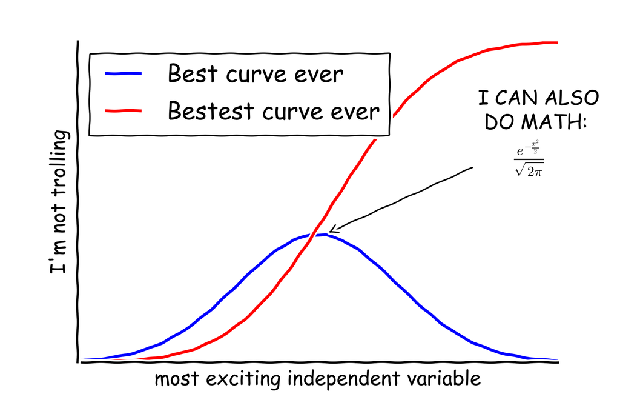

/>See https://www.xkcd.com

```python
"""
Simple demo of a scatter plot.
"""
# import numpy as np
# import matplotlib.pyplot as plt


N = 50
x = np.random.rand(N)
y = np.random.rand(N)
colors = np.random.rand(N)
area = np.pi * (15 * np.random.rand(N))**2  # 0 to 15 point radiuses

plt.scatter(x, y, s=area, c=colors, alpha=0.5)
plt.savefig("./graphics/scatter_demo.png", dpi=200)
```

[output not shown]

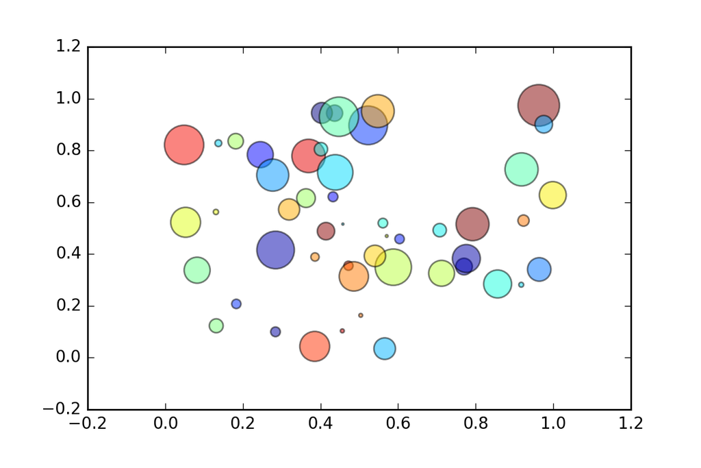

/>http://matplotlib.org/gallery.html

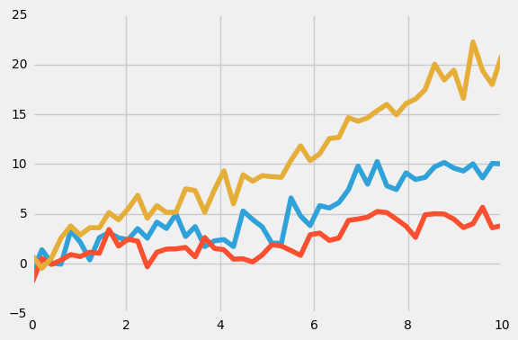

```python
"""
This shows an example of the "fivethirtyeight" styling, which
tries to replicate the styles from FiveThirtyEight.com.
"""


from matplotlib import pyplot as plt
import numpy as np

x = np.linspace(0, 10)

with plt.style.context('fivethirtyeight'):
    plt.plot(x, np.sin(x) + x + np.random.randn(50))
    plt.plot(x, np.sin(x) + 0.5 * x + np.random.randn(50))
    plt.plot(x, np.sin(x) + 2 * x + np.random.randn(50))

plt.savefig("./graphics/fivethirtyeight_demo.png", dpi=200)
```

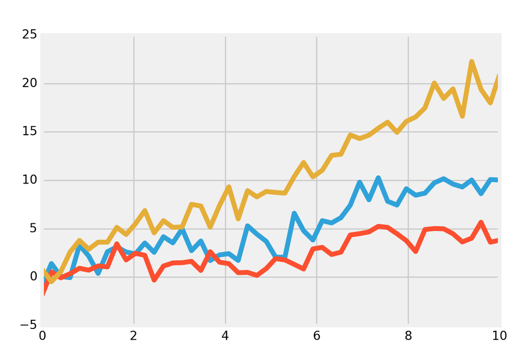

/>http://matplotlib.org/gallery.html

# Jupyter notebooks

www.jupyter.org

# Jupyter what?

- Interactive scientific computing environment
  - Data analysis and visualization
  - Interactive reports
  - Parallel computing!
- Originated from the IPython project in 2014
- Now supports a number of languages (Python, BASH, ...)

# Jupyter notebooks

- Interactive documents that combine
  - Executable code
  - Rich-text elements ([**Markdown**](https://en.wikipedia.org/wiki/Markdown) + HTML)
- They are **text-based** (Git anyone?)

# More cool stuff

LaTex support and syntax highlighting

Write

```
\begin{equation}
 \Sigma (\omega) = \int \, d\omega' ...
\end{equation}
```

and get \begin{equation} \Sigma (\omega) = \int \, d\omega' ... \end{equation}

# TO DEMO OR NOT TO DEMO?

Also remember to convert to pdf!

# Conclusion

- **Git**: an essential tool for any workflow
  - tracking of personal work
  - easy collaborative work
- **Jupyter** - Great for:
  - Data analysis
  - Reports
  - (Works best with Python)

# Resources

## Git

- http://rogerdudler.github.io/git-guide/
- https://git-scm.com/book/en/v2/Getting-Started-Git-Basics

## Jupyter notebooks

- [Beginner video tutorial](https://www.youtube.com/watch?v=HW29067qVWk)
- [Notebooks gallery](https://github.com/ipython/ipython/wiki/A-gallery-of-interesting-IPython-Notebooks)

## Markdown

- https://help.github.com/articles/getting-started-with-writing-and-formatting-on-github/
- https://guides.github.com/features/mastering-markdown/

# Bonus clip

How do you think these slides were made?

# Sol 1116

## Meta-presentation aimed at explaining the very tools that created itself.

[View on GitHub](https://github.com/teoguso/sol_1116) [Download .zip](https://github.com/teoguso/sol_1116/zipball/master) [Download .tar.gz](https://github.com/teoguso/sol_1116/tarball/master)

# Jupyter Notebook + Reveal.js = Beautiful Slides

A first attempt to produce a decent-looking presentation using jupyter notebooks and reveal.js.

To obtain the slides one requires to have the 'reveal.js' directory in the same directory as the notebook. Then type in bash

```
jupyter-nbconvert --to slides Presentation1.ipynb --reveal-prefix=reveal.js
```

to obtain the slides in HTML format. A static copy of the reveal.js repo is included here. The original repo is at https://github.com/hakimel/reveal.js/

## Notebook-to-pdf

To use nbconvert nice feature, just type `jupyter-nbconvert --to pdf cumulant-to-pdf.ipynb` this will produce a pdf-from-latex file from the notebook. Enjoy it with your viewer of choice.

## Slides-to-pdf

This is a little hacky, as explained in [this blogpost](http://www.damian.oquanta.info/posts/a-little-hack-to-get-a-pdf-from-your-ipython-slides.html) by [@damianavila](https://github.com/damianavila). I already included the two necessary files in the source. As also specified in the post, it seems to work only with mozilla firefox/iceweasel (do not trust the webpage you'll see, check the pdf output). Also, I have issues in rendering all the images (which means most of them do not render). Oh well.